# Generating pairwise plots of maximum gene expression between oosporogenesis and oospore conversion

Path to the shared folder:

```r
sharedPath <- "/isilon/biodiversity/users/shared/Pythium_ultimum_RNAseq/"
```

Read file with all the data. This file was made after normalizing oosporogenesis and oospore conversion together with EdgeR

```r
rpkmPlotsFullImport <- read.table(paste(sharedPath,
                                        "rpkmForBarPlots_full.csv",
                                        sep = ""),
                                  sep = ",",
                                  header = TRUE,
                                  as.is = TRUE,
                                  stringsAsFactors = FALSE)

#This is to create a lingle variable that creates a single variable that separates the 7 oosporegenesis treatments
rpkmPlotsFullImport$xLab <- paste(rpkmPlotsFullImport$Condition,
                                  rpkmPlotsFullImport$TimePoint,
                                  sep = "_")
unique(rpkmPlotsFullImport$xLab)
```

```
##  [1] "Various_0"         "OoCTimeCourse_0"   "Control_0"
##  [4] "OoCTimeCourse_12"  "OoCTimeCourse_120" "OoCTimeCourse_24"
##  [7] "Control_24"        "Cholesterol_24"    "OoCTimeCourse_240"
## [10] "Control_3"         "Cholesterol_3"     "OoCTimeCourse_48"
## [13] "Control_7"         "Cholesterol_7"     "OoCTimeCourse_72"
```

```r
# To clean up the other experiments
rpkmPlotsFullImport$xLab <- sub("OoCTimeCourse_", "", rpkmPlotsFullImport$xLab)
rpkmPlotsFullImport$xLab <- sub("Various_0", "Various", rpkmPlotsFullImport$xLab)
unique(rpkmPlotsFullImport$xLab)
```

```
##  [1] "Various"        "0"              "Control_0"      "12"
##  [5] "120"            "24"             "Control_24"     "Cholesterol_24"
##  [9] "240"            "Control_3"      "Cholesterol_3"  "48"
## [13] "Control_7"      "Cholesterol_7"  "72"
```

```r
unique(rpkmPlotsFullImport$Experiment)
```

```
## [1] "Mycelium"          "OosporeConversion" "Oosporogenesis"
```

```r
# Creates orderes factors (very important for plotting)
labOrdered <- c("Various", "Control_0", "Control_3", "Cholesterol_3",
                "Control_7", "Cholesterol_7", "Control_24", "Cholesterol_24",
                "0", "12", "24", "48", "72", "120", "240")
rpkmPlotsFullImport$xLab <- factor(rpkmPlotsFullImport$xLab, levels = c(labOrdered))
levels(rpkmPlotsFullImport$xLab)
```

```
##  [1] "Various"        "Control_0"      "Control_3"      "Cholesterol_3"
##  [5] "Control_7"      "Cholesterol_7"  "Control_24"     "Cholesterol_24"
##  [9] "0"              "12"             "24"             "48"
## [13] "72"             "120"            "240"
```

```r
expOrdered <- c("Mycelium", "Oosporogenesis", "OosporeConversion")
rpkmPlotsFullImport$Experiment <- factor(rpkmPlotsFullImport$Experiment,
                                         levels = c(expOrdered))
levels(rpkmPlotsFullImport$Experiment)
```

```
## [1] "Mycelium"          "Oosporogenesis"    "OosporeConversion"
```

```r
rm(expOrdered)
rm(labOrdered)

# note, there is a bug in the way RNA replicate was carried forward (probably because levels were used instead of actual numbers), this is why Exp_Unit is being used to rebuild it here.
rpkmPlotsFullImport$RNA_Rep <- sub("^T","", rpkmPlotsFullImport$ExpUnit)
rpkmPlotsFullImport$RNA_Rep <- sub("^[0-9]+-","", rpkmPlotsFullImport$RNA_Rep)
rpkmPlotsFullImport$RNA_Rep <- sub("^c|^x","", rpkmPlotsFullImport$RNA_Rep)
rpkmPlotsFullImport$RNA_Rep <- sub("\\.","", rpkmPlotsFullImport$RNA_Rep)
rpkmPlotsFullImport$RNA_Rep <- sub("^[A-z]*.[A-z]$","1", rpkmPlotsFullImport$RNA_Rep)
rpkmPlotsFullImport$RNA_Rep <- sub("emp35C","1", rpkmPlotsFullImport$RNA_Rep)

levels(as.factor(rpkmPlotsFullImport$RNA_Rep))
```

```
## [1] "1" "2" "3" "4"
```

Add a column in the large data file about being CAZy (secreted or not) on non CAZy

```r
mainFolder <- "GGPLOTS_FROM_FULL_DATA_continuous_X/from_Emily_24_March_2017"


listLoci <- read.table(paste(sharedPath, mainFolder, "/CAZy_of_interest_list.csv", sep = ""),
                                  sep = ",",header = TRUE, as.is = TRUE,  stringsAsFactors = FALSE)

# Note that I am not using the fread command from data.table.  This one creates a real problem later as column indexing no longer works with data,
# table that has the feature of usinf<g column names instead.  A real problem if you want to use columns in a loop.
# library(data.table)
# listLoci <- fread(paste(sharedPath, mainFolder, "/CAZy_of_interest_list.csv", sep = ""),
#                   sep = "auto", header = TRUE)
```

Show duplicated secreted genes

```r
Secreted_duplicated <-  listLoci[which(listLoci$Secreted=="secreted"),]
Secreted_duplicated[duplicated(Secreted_duplicated$SequenceID),]
```

```
##       X   SequenceID CAZyFamily Secreted
## 44   44 PYU1_T001346       GH13 secreted
## 182 182 PYU1_T005443       GH15 secreted
## 185 185 PYU1_T005445       GH15 secreted
## 213 213 PYU1_T006194       GH31 secreted
## 374 374 PYU1_T013005       GT31 secreted
##                                                                                                  geneInfo
## 44       PYU1_T001346 - secreted - candidate a-glycosidase (a-amylase related)%3B N-terminal CBM25 module
## 182 PYU1_T005443 - secreted - candidate a-glycosidase related to glucoamylases%3B N-terminal CBM21 module
## 185 PYU1_T005445 - secreted - candidate a-glycosidase related to glucoamylases%3B N-terminal CBM21 module
## 213                                                     PYU1_T006194 - secreted - candidate a-glycosidase
## 374                                   PYU1_T013005 - secreted - distantly related to glycosyltransferases
##                                                                                                  geneInfoTab
## 44       PYU1_T001346 - secreted \n candidate a-glycosidase (a-amylase related)%3B N-terminal\nCBM25 module
## 182 PYU1_T005443 - secreted \n candidate a-glycosidase related to glucoamylases%3B\nN-terminal CBM21 module
## 185 PYU1_T005445 - secreted \n candidate a-glycosidase related to glucoamylases%3B\nN-terminal CBM21 module
## 213                                                     PYU1_T006194 - secreted \n candidate a-glycosidase\n
## 374                                   PYU1_T013005 - secreted \n distantly related to glycosyltransferases\n
```

Aggregate together CAZy families for genes with more than one family, and remove duplicated

```r
dat_agg <- aggregate(listLoci[,c(2,3)], by=list(listLoci$SequenceID),FUN=c)
for(i in 1:length(dat_agg$CAZyFamily)){
  dat_agg$CAZyFamily2[i] <-paste(unlist(dat_agg$CAZyFamily[i]), collapse="-")
}

dat_agg$SequenceID <- NULL
colnames(dat_agg)[1] <- "SequenceID"
dat_agg$CAZyFamily <- NULL
colnames(dat_agg)[2] <- "CAZyFamily"

#remove duplicated loci
listLoci <- listLoci[!duplicated(listLoci$SequenceID),]
listLoci$CAZyFamily <- NULL
#replace names with concatenated names
listLoci <- merge(listLoci, dat_agg, by= "SequenceID")
```

Integrate gene loci CAZy and secreted data into main data table and write non-CAZy for NA

```r
rpkmPlotsFullImport <- merge(listLoci[,c(1,3,6)], rpkmPlotsFullImport[,2:10], by = "SequenceID", all.y = TRUE)
rpkmPlotsFullImport$Secreted[is.na(rpkmPlotsFullImport$Secreted)] <- "non-CAZy"
rpkmPlotsFullImport$CAZyFamily[is.na(rpkmPlotsFullImport$CAZyFamily)] <- "non-CAZy"
```

Create Main plot folder

```r
mainFolder <- "GGPLOTS_STATS_FROM_FULL_DATA_pairwise_comparisons"

if (dir.exists(paste(sharedPath, mainFolder , sep = ""))) {} else {
  dir.create(paste(sharedPath, mainFolder , sep = ""), showWarnings = TRUE, recursive = FALSE)  }
```

Create a folder for the plot outputs:

```r
analysisDir <- "29_Aug_2017_annotated_script"
if (dir.exists(paste(sharedPath, mainFolder , "/", analysisDir, sep = ""))) {} else {
  dir.create(paste(sharedPath, mainFolder , "/", analysisDir, sep = ""), showWarnings = TRUE, recursive = FALSE)  }
```

```r
analysisPath <- paste(sharedPath, mainFolder , "/", analysisDir, sep = "")
```

Creating log10 + 1 read

```r
library(doBy)
rpkmPlotsFullImport$log_Read_Counts <- log10(rpkmPlotsFullImport$Read_Counts + 1)
head(rpkmPlotsFullImport)
```

```
##     SequenceID Secreted CAZyFamily      ExpUnit Read_Counts     Condition
## 1 PYU1_T000001 non-CAZy   non-CAZy At.Infection    2.768016       Various
## 2 PYU1_T000001 non-CAZy   non-CAZy      Hypoxia    0.380560       Various
## 3 PYU1_T000001 non-CAZy   non-CAZy  Mefenoxam.C    1.159743       Various
## 4 PYU1_T000001 non-CAZy   non-CAZy  Mefenoxam.T    0.311428       Various
## 5 PYU1_T000001 non-CAZy   non-CAZy         T0-1    0.000000 OoCTimeCourse
## 6 PYU1_T000001 non-CAZy   non-CAZy         T0-2    0.000000 OoCTimeCourse
##   TimePoint RNA_Replicate        Experiment    xLab RNA_Rep
## 1         0             1          Mycelium Various       1
## 2         0             1          Mycelium Various       1
## 3         0             1          Mycelium Various       1
## 4         0             1          Mycelium Various       1
## 5         0             1 OosporeConversion       0       1
## 6         0             3 OosporeConversion       0       2
##   log_Read_Counts
## 1       0.5761127
## 2       0.1400553
## 3       0.3344021
## 4       0.1177445
## 5       0.0000000
## 6       0.0000000
```

Create a Table with mean by experimental unit and remove time 0 (except for mycelium=Various).

```r
mean_per_exp <- summaryBy(log_Read_Counts ~ SequenceID + CAZyFamily + Secreted + Experiment + Condition + TimePoint, data=rpkmPlotsFullImport, FUN = c(mean) )

mean_per_exp_no_time0  <- mean_per_exp[which(mean_per_exp$TimePoint != 0 | mean_per_exp$Condition =="Various"),]

mean_per_exp_no_time0[1:20,]
```

```
##      SequenceID CAZyFamily     Secreted        Experiment     Condition
## 1  PYU1_T000001   non-CAZy     non-CAZy          Mycelium       Various
## 2  PYU1_T000001   non-CAZy     non-CAZy    Oosporogenesis   Cholesterol
## 3  PYU1_T000001   non-CAZy     non-CAZy    Oosporogenesis   Cholesterol
## 4  PYU1_T000001   non-CAZy     non-CAZy    Oosporogenesis   Cholesterol
## 6  PYU1_T000001   non-CAZy     non-CAZy    Oosporogenesis       Control
## 7  PYU1_T000001   non-CAZy     non-CAZy    Oosporogenesis       Control
## 8  PYU1_T000001   non-CAZy     non-CAZy    Oosporogenesis       Control
## 10 PYU1_T000001   non-CAZy     non-CAZy OosporeConversion OoCTimeCourse
## 11 PYU1_T000001   non-CAZy     non-CAZy OosporeConversion OoCTimeCourse
## 12 PYU1_T000001   non-CAZy     non-CAZy OosporeConversion OoCTimeCourse
## 13 PYU1_T000001   non-CAZy     non-CAZy OosporeConversion OoCTimeCourse
## 14 PYU1_T000001   non-CAZy     non-CAZy OosporeConversion OoCTimeCourse
## 15 PYU1_T000001   non-CAZy     non-CAZy OosporeConversion OoCTimeCourse
## 16 PYU1_T000002      GH109 not secreted          Mycelium       Various
```

[output cut: 27 more lines]

Find the maximum for each experiment, keeping cholesterol and control separate.

```r
max_per_exp <- summaryBy(log_Read_Counts.mean ~ SequenceID + CAZyFamily + Secreted + Experiment + Condition, data=mean_per_exp_no_time0, FUN = c(max) )
head(max_per_exp)
```

```
##     SequenceID CAZyFamily     Secreted        Experiment     Condition
## 1 PYU1_T000001   non-CAZy     non-CAZy          Mycelium       Various
## 2 PYU1_T000001   non-CAZy     non-CAZy    Oosporogenesis   Cholesterol
## 3 PYU1_T000001   non-CAZy     non-CAZy    Oosporogenesis       Control
## 4 PYU1_T000001   non-CAZy     non-CAZy OosporeConversion OoCTimeCourse
## 5 PYU1_T000002      GH109 not secreted          Mycelium       Various
## 6 PYU1_T000002      GH109 not secreted    Oosporogenesis   Cholesterol
##   log_Read_Counts.mean.max
## 1                0.2537873
## 2                0.3059499
## 3                0.2579587
## 4                1.1855532
## 5                1.9282937
## 6                0.3748193
```

Reorganize this table to have different columns for experiment, so one line per gene

```r
library(reshape2)
counts_for_pairwise_no_T0 <- dcast(data = max_per_exp, SequenceID + CAZyFamily + Secreted  ~ Condition, value.var = "log_Read_Counts.mean.max")
head(counts_for_pairwise_no_T0)
```

```
##     SequenceID CAZyFamily     Secreted Cholesterol   Control OoCTimeCourse
## 1 PYU1_T000001   non-CAZy     non-CAZy   0.3059499 0.2579587      1.185553
## 2 PYU1_T000002      GH109 not secreted   0.3748193 0.9210091      1.307236
## 3 PYU1_T000003   non-CAZy     non-CAZy   1.5990520 1.2378438      1.509190
## 4 PYU1_T000004   non-CAZy     non-CAZy   1.3177631 1.3989731      1.237183
## 5 PYU1_T000005       GT20 not secreted   1.7610545 1.9385288      1.894440
## 6 PYU1_T000006      GH109 not secreted   1.3981749 1.3013154      1.503427
##     Various
## 1 0.2537873
## 2 1.9282937
## 3 1.2202877
## 4 0.8151318
## 5 1.5394466
## 6 1.8998455
```

Subset only secreted CAZy. Carried all data up to here in case one wanted to do more plots with other genes.

```r
subset_count <-  counts_for_pairwise_no_T0[which(counts_for_pairwise_no_T0$Secreted=="secreted"),]
```

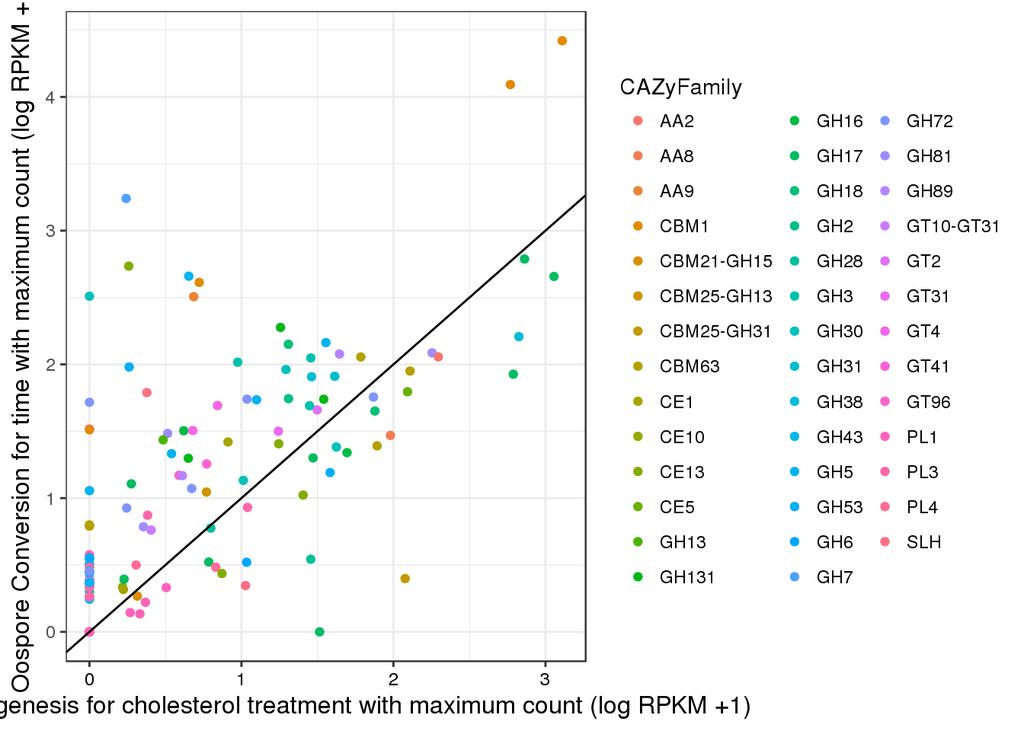

```r
library(ggplot2)
#Condition.vars <- c("Cholesterol", "Control", "OoCTimeCourse", "Various")


p0 <-   ggplot(aes(y= OoCTimeCourse, x= Cholesterol, colour=CAZyFamily), data = subset_count) +
   ylab("Oospore Conversion for time with maximum count (log RPKM +1)") +
     xlab("Oosporogenesis for cholesterol treatment with maximum count (log RPKM +1)") +
    geom_point() +
  geom_abline(intercept = 0, slope = 1) +
  theme_bw() +
  theme(axis.text.x = element_text(colour = 'black', size = 9, angle = 0, hjust = 0.5, vjust = 1.0, face= "plain")) +
  theme(axis.title.y = element_text(colour = 'black', size = 12, angle = 90, hjust = 0.5, vjust = 1.0, face= "plain")) +
    theme(axis.title.x = element_text(colour = 'black', size = 12, angle = 0, hjust = 0.5, vjust = 1.0, face= "plain"))
 print(p0)
```

Vector plot

```r
  svg(file   = paste(sharedPath, "/", mainFolder, "/", analysisDir, "/",  "Secreted_CZAy_correlations.svg", sep=""),
      width  = 10,
      height = 8,
      bg     = "white")
print(p0)
dev.off()
```

```r
  png(file   = paste(sharedPath, "/", mainFolder, "/", analysisDir, "/",  "Secreted_CZAy_correlations.png", sep=""),
      width  = 10,
      height = 8,
      units  = "in",
      res    = 600,
      bg     = "white")
print(p0)
dev.off()
```

pdf plot

```r
pdf(file = paste(sharedPath, "/", mainFolder, "/", analysisDir, "/",  "Secreted_CZAy_correlations.pdf", sep="") , width = 10, height = 8)
print(p0)
dev.off()
```

Correlation plot by family

[figure not shown]

```r
p1 <-   ggplot(aes(y= OoCTimeCourse, x= Various, colour=Secreted), data = subset_count) +
    geom_point() +
  geom_abline(intercept = 0, slope = 1) +
    facet_wrap(~CAZyFamily, ncol=4, scales = "free") +
  theme_bw() +
  theme(axis.text.x = element_text(colour = 'black', size = 9, angle = 0, hjust = 1, vjust = 1.0, face= "italic")) +
  theme(strip.text.x = element_text(size = 8))
print(p1)
```

```r
pdf(file = paste(sharedPath, "/", mainFolder, "/", analysisDir, "/", "facet_correlations.pdf", sep="") , width = 8, height = 40)
print(p1)
dev.off()
```

```r
write.table(subset_count,  paste(sharedPath, "/", mainFolder, "/", analysisDir, "/", "Table_for_correlations.csv", sep=""), append = FALSE, quote = TRUE, sep = ",",
        col.names = NA, row.names = TRUE)
```

With the four different variables

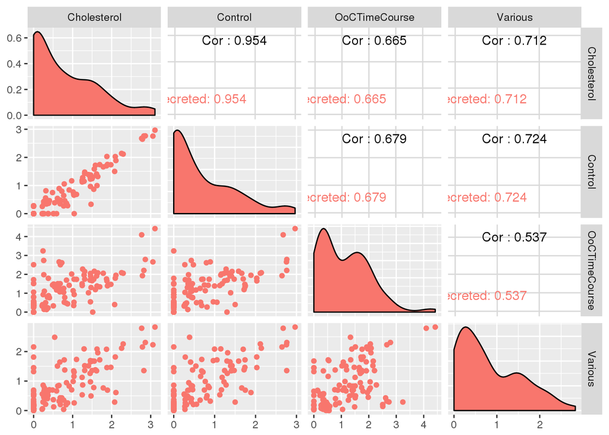

```r
library("GGally")
g1 <- ggpairs(data=subset_count, columns= 4:7, mapping=ggplot2::aes(colour = Secreted), lower=list(combo=wrap("facethist",binwidth=1,  alpha = 0.3)))
print(g1)
```

Print to pdf

```r
pdf(file = paste(sharedPath, "/", mainFolder, "/", analysisDir, "/", "Matrix_plot_correlations.pdf", sep="") , width = 8, height = 8)
print(g1)
dev.off()
```